# COVID19 Mortality rate prediction. IML ’20 Homework 1.

Łukasz Grad

Read and show raw data.

```r
common_cols = intersect(colnames(covid_hubei), colnames(covid_outside))
covid = covid_hubei %>%
    mutate(admin_id = as.character(admin_id)) %>%
    bind_rows(covid_outside) %>%
    select(common_cols)
covid %>% head
```

| ID | age | sex | city | province | country | wuhan(0)_not_wuhan(1) | latitude | longitude | geo_resolution | date_onset_symptoms | date_admission_hospital | date_confirmation | symptoms | lives_in_Wuhan | travel_history_dates | travel_history_location | reported_market_exposure | additional_information | chronic_disease_binary | chronic_disease | source | sequence_available | outcome | date_death_or_discharge | notes_for_discussion | location | admin3 | admin2 | admin1 | … |
| --- | --- | --- | --- | --- | --- | --- | --- | --- | --- | --- | --- | --- | --- | --- | --- | --- | --- | --- | --- | --- | --- | --- | --- | --- | --- | --- | --- | --- | --- | --- |
| 1 | 15-88 | male | Wuhan City | Hubei | China | 0 | 30.62506 | 114.3421 | admin2 | pre 18.01.2020 | NA | 20.01.2020 | NA | NA | NA | NA | NA | NA | NA | NA | http://wjw.wuhan.gov.cn/front/web/showDetail/2020012109085 | NA | NA | NA | NA | NA | NA | Wuhan City | Hubei | … |
| 2 | 15-88 | male | Wuhan City | Hubei | China | 0 | 30.62506 | 114.3421 | admin2 | pre 18.01.2020 | NA | 20.01.2020 | NA | NA | NA | NA | NA | NA | NA | NA | http://wjw.wuhan.gov.cn/front/web/showDetail/2020012109085 | NA | NA | NA | NA | NA | NA | Wuhan City | Hubei | … |
| 3 | 15-88 | male | Wuhan City | Hubei | China | 0 | 30.62506 | 114.3421 | admin2 | pre 18.01.2020 | NA | 20.01.2020 | NA | NA | NA | NA | NA | NA | NA | NA | http://wjw.wuhan.gov.cn/front/web/showDetail/2020012109085 | NA | NA | NA | NA | NA | NA | Wuhan City | Hubei | … |
| 4 | 15-88 | male | Wuhan City | Hubei | China | 0 | 30.62506 | 114.3421 | admin2 | pre 18.01.2020 | NA | 20.01.2020 | NA | NA | NA | NA | NA | NA | NA | NA | http://wjw.wuhan.gov.cn/front/web/showDetail/2020012109085 | NA | NA | NA | NA | NA | NA | Wuhan City | Hubei | … |
| 5 | 15-88 | male | Wuhan City | Hubei | China | 0 | 30.62506 | 114.3421 | admin2 | pre 18.01.2020 | NA | 20.01.2020 | NA | NA | NA | NA | NA | NA | NA | NA | http://wjw.wuhan.gov.cn/front/web/showDetail/2020012109085 | NA | NA | NA | NA | NA | NA | Wuhan City | Hubei | … |
| 6 | 15-88 | male | Wuhan City | Hubei | China | 0 | 30.62506 | 114.3421 | admin2 | pre 18.01.2020 | NA | 20.01.2020 | NA | NA | NA | NA | NA | NA | NA | NA | http://wjw.wuhan.gov.cn/front/web/showDetail/2020012109085 | NA | NA | NA | NA | NA | NA | Wuhan City | Hubei | … |

We have a lot of missing values and data in general is messy. The column of interest is “outcome”

```r
covid %>%
    summarise_all(~ mean(is.na(.)))
```

| ID | age | sex | city | province | country | wuhan(0)_not_wuhan(1) | latitude | longitude | geo_resolution | date_onset_symptoms | date_admission_hospital | date_confirmation | symptoms | lives_in_Wuhan | travel_history_dates | travel_history_location | reported_market_exposure | additional_information | chronic_disease_binary | chronic_disease | source | sequence_available | outcome | date_death_or_discharge | notes_for_discussion | location | admin3 | admin2 | admin1 | … |
| --- | --- | --- | --- | --- | --- | --- | --- | --- | --- | --- | --- | --- | --- | --- | --- | --- | --- | --- | --- | --- | --- | --- | --- | --- | --- | --- | --- | --- | --- | --- |
| 2.463722e-05 | 0.9494444 | 0.9526719 | 0.1813299 | 0.02444012 | 0.0006652049 | 2.463722e-05 | 0.0003695583 | 0.0003695583 | 0 | 0.9781468 | 0.9797975 | 0.02347927 | 0.9854887 | 0.9843307 | 0.9842322 | 0.969918 | 0.9989899 | 0.9245362 | 0.9987435 | 0.9991131 | 0.005494099 | 0.9999015 | 0.9941856 | 0.9964276 | 0.9953436 | 0.9557762 | 0.9583138 | 0.2500924 | 0.05058021 | … |

We have 59 cases of confirmed deaths.

```r
death_vals = c('death', 'died')
covid %>% filter(outcome %in% death_vals)
```

| ID | age | sex | city | province | country | wuhan(0)_not_wuhan(1) | latitude | longitude | geo_resolution | date_onset_symptoms | date_admission_hospital | date_confirmation | symptoms | lives_in_Wuhan | travel_history_dates | travel_history_location | reported_market_exposure | additional_information | chronic_disease_binary | chronic_disease | source | sequence_available | outcome | date_death_or_discharge | notes_for_discussion | location | admin3 | admin2 | admin1 | … |
| --- | --- | --- | --- | --- | --- | --- | --- | --- | --- | --- | --- | --- | --- | --- | --- | --- | --- | --- | --- | --- | --- | --- | --- | --- | --- | --- | --- | --- | --- | --- |
| 60 | 15-88 | female | Wuhan City | Hubei | China | 0 | 30.62506 | 114.342100 | admin2 | 10.12.2019 | 31.12.2019 | NA | dyspnea, respiratory stress | NA | NA | NA | NA | NA | NA | NA | http://wjw.wuhan.gov.cn/front/web/showDetail/2020012109085 | NA | died | NA | NA | NA | NA | Wuhan City | Hubei | … |
| 61 | 66 | male | Wuhan City | Hubei | China | 0 | 30.62506 | 114.342100 | admin2 | 10.01.2020 | 16.01.2020 | NA | cough, fatigue, fever, headache | NA | NA | NA | NA | Chronic diseases: hypertension, chronic obstructive pulmonary disease, diabetes, chronic renal insufficiency | 1 | hypertension, chronic obstructive pulmonary disease, diabetes, chronic renal insufficiency | http://wjw.wuhan.gov.cn/front/web/showDetail/2020012109085 | NA | died | 20.01.2020 | NA | NA | NA | Wuhan City | Hubei | … |
| 62 | 48 | female | Wuhan City | Hubei | China | 0 | 30.62506 | 114.342100 | admin2 | 10.12.2019 | 10.12.2019 | NA | cough, fatigure, fever, little sputum, muscular soreness | yes | NA | NA | NA | Chronic diseases: diabetes, cerebral infarction | 1 | diabetes, cerebral infarction | http://wjw.wuhan.gov.cn/front/web/showDetail/2020012009077 | NA | died | 20.01.2020 | NA | NA | NA | Wuhan City | Hubei | … |
| 63 | 89 | male | Wuhan City | Hubei | China | 0 | 30.62506 | 114.342100 | admin2 | 13.01.2020 | 18.01.2020 | 18.01.2020 | dyspnea | yes | NA | NA | NA | Chronic diseases: hypertension, diabetes, coronary heart disease, frequent ventricular premature beat (FVPB), coronary artery stenting | 1 | hypertension, diabetes, coronary heart disease, frequent ventricular premature beat (FVPB), coronary artery stenting | http://wjw.wuhan.gov.cn/front/web/showDetail/2020012109085 | NA | died | 19.01.2020 | NA | NA | NA | Wuhan City | Hubei | … |
| 64 | 61 | male | Wuhan City | Hubei | China | 0 | 30.62506 | 114.342100 | admin2 | 20.12.2019 | 27.12.2019 | NA | NA | yes | NA | NA | NA | NA | NA | NA | https://www.nejm.org/doi/full/10.1056/NEJMoa2001017 | yes | died | 09.01.2020 | NA | NA | NA | Wuhan City | Hubei | … |
| 65 | 69 | male | Wuhan City | Hubei | China | 0 | 30.62506 | 114.342100 | admin2 | 30.12.2019 | 03.01.2020 | NA | cough, fever | yes | NA | NA | NA | NA | NA | NA | http://www.nhc.gov.cn/yjb/s3578/202001/5d19a4f6d3154b9fae328918ed2e3c8a.shtml | NA | died | 15.01.2020 | NA | NA | NA | Wuhan City | Hubei | … |
| 66 | 89 | male | Wuhan City | Hubei | China | 0 | 30.62506 | 114.342100 | admin2 | 05.01.2020 | 05.01.2020 | NA | obnubilation, somnolence | yes | NA | NA | NA | Chronic diseases: hypertension, cerebral infarction, encephalomalacia | 1 | hypertension, cerebral infarction, encephalomalacia | http://www.nhc.gov.cn/yjb/s3578/202001/5d19a4f6d3154b9fae328918ed2e3c8a.shtml | NA | died | 18.01.2020 | NA | NA | NA | Wuhan City | Hubei | … |
| 67 | 75 | male | Wuhan City | Hubei | China | 0 | 30.62506 | 114.342100 | admin2 | 06.01.2020 | 11.01.2020 | NA | cough, expectoration, emesis, fever | yes | NA | NA | NA | Chronic diseases: hypertension, hip replacement | 1 | hypertension, hip replacement | http://www.nhc.gov.cn/yjb/s3578/202001/5d19a4f6d3154b9fae328918ed2e3c8a.shtml | NA | died | 20.01.2020 | NA | NA | NA | Wuhan City | Hubei | … |
| 68 | 82 | male | Wuhan City | Hubei | China | 0 | 30.62506 | 114.342100 | admin2 | 09.01.2020 | 14.01.2020 | NA | cold chills, muscular soreness | yes | NA | NA | NA | NA | NA | NA | http://www.nhc.gov.cn/yjb/s3578/202001/5d19a4f6d3154b9fae328918ed2e3c8a.shtml | NA | died | 21.01.2020 | NA | NA | NA | Wuhan City | Hubei | … |
| 69 | 66 | male | Wuhan City | Hubei | China | 0 | 30.62506 | 114.342100 | admin2 | 22.12.2019 | 31.12.2019 | NA | dry cough | yes | NA | NA | NA | NA | NA | NA | http://www.nhc.gov.cn/yjb/s3578/202001/5d19a4f6d3154b9fae328918ed2e3c8a.shtml | NA | died | 21.01.2020 | NA | NA | NA | Wuhan City | Hubei | … |

[output cut: 49 more lines]

Let’s see the most common early symptoms

```r
symptoms_data = lapply(covid$symptoms, clean_string)
symptoms_all = Reduce(c, symptoms_data)
symptoms_all_sorted = sort(table(symptoms_all), decreasing = T)
symptoms_all_sorted[1:15]
```

```
## symptoms_all
##       fever       cough        sore      throat     fatigue        pain
##         430         226          43          43          35          26
##    headache       chest      chills pneumonitis        nose   pneumonia
##          21          20          20          19          17          17
##       runny           c     dyspnea
##          17          14          14
```

Prepare clean dataset and show some plots

```r
frequent_countries = c('china')
frequent_symptoms = c('pneumonia|pneumonitis', 'pain', 'fever',
                      'cough', 'sore throat', 'fatigue', 'headache', 'dyspnea')

covid_train = covid %>%
    mutate(
        outcome = ifelse(outcome %in% death_vals, 'dead', 'recovered'),
        country = ifelse(tolower(country) %in% frequent_countries, country, 'other'),
        in_wuhan = !as.logical(`wuhan(0)_not_wuhan(1)`),
        age = ifelse(str_detect(age, "[:digit:]{2}-[:digit:]{2}"),
                     0.5 * as.numeric(str_sub(age, 1, 2)) + 0.5 * as.numeric(str_sub(age, 3, 4)),
                     as.numeric(age)),
        sex = tolower(sex),
        chronic_disease = ifelse(is.na(chronic_disease_binary),
                                'NA',
                                as.character(chronic_disease_binary))
    ) %>%
    select(age, sex, country, chronic_disease, outcome, in_wuhan, symptoms) %>%
    filter(!is.na(age)) %>%
    filter(!is.na(sex))
for (symptom in frequent_symptoms) {
    covid_train[symptom] = str_detect(symptom, covid_train$symptoms)
    covid_train[symptom][is.na(covid_train[symptom])] = F
}

covid_train = covid_train %>% select(-symptoms)

covid_train %>% head
```

| age | sex | country | chronic_disease | outcome | in_wuhan | pneumonia\|pneumonitis | pain | fever | cough | sore throat | fatigue | headache | dyspnea |
| --- | --- | --- | --- | --- | --- | --- | --- | --- | --- | --- | --- | --- | --- |
| 3.5 | male | China | NA | recovered | TRUE | FALSE | FALSE | FALSE | FALSE | FALSE | FALSE | FALSE | FALSE |
| 3.5 | male | China | NA | recovered | TRUE | FALSE | FALSE | FALSE | FALSE | FALSE | FALSE | FALSE | FALSE |
| 3.5 | male | China | NA | recovered | TRUE | FALSE | FALSE | FALSE | FALSE | FALSE | FALSE | FALSE | FALSE |
| 3.5 | male | China | NA | recovered | TRUE | FALSE | FALSE | FALSE | FALSE | FALSE | FALSE | FALSE | FALSE |
| 3.5 | male | China | NA | recovered | TRUE | FALSE | FALSE | FALSE | FALSE | FALSE | FALSE | FALSE | FALSE |
| 3.5 | male | China | NA | recovered | TRUE | FALSE | FALSE | FALSE | FALSE | FALSE | FALSE | FALSE | FALSE |

China has more deaths, age is heavily influencing mortality rate.

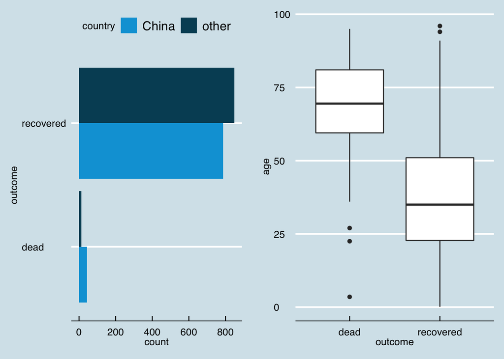

```r
p1 = covid_train %>%
    ggplot(aes(outcome, fill = country)) +
    geom_bar(position = 'dodge') +
    scale_fill_economist() +
    coord_flip()

p2 = covid_train %>%
    ggplot(aes(outcome, age)) +
    geom_boxplot()

grid.arrange(p1, p2, nrow = 1)
```

Chronic disease is critical for the outcome, but data may be biased. It is also heavily correlated with age.

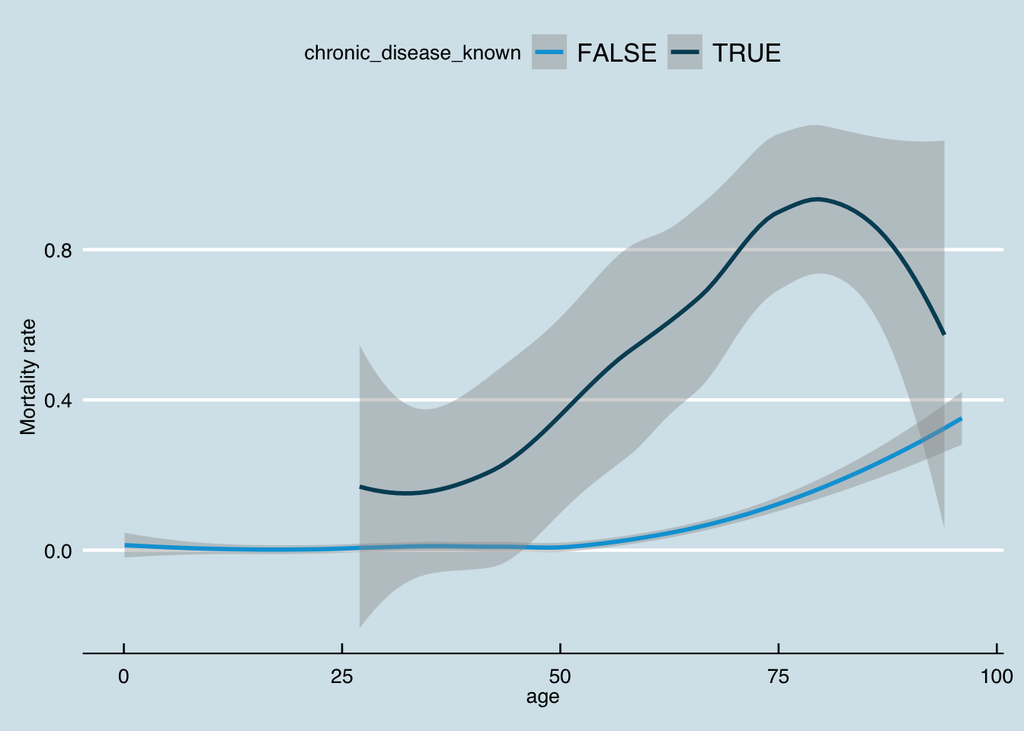

```r
covid_train %>%
    mutate(chronic_disease_known = as.factor(chronic_disease == '1')) %>%
    ggplot(aes(age, as.numeric(outcome == 'dead'), colour = chronic_disease_known)) +
    geom_smooth(method = 'loess') +
    scale_color_economist() +
    ylab('Mortality rate')
```

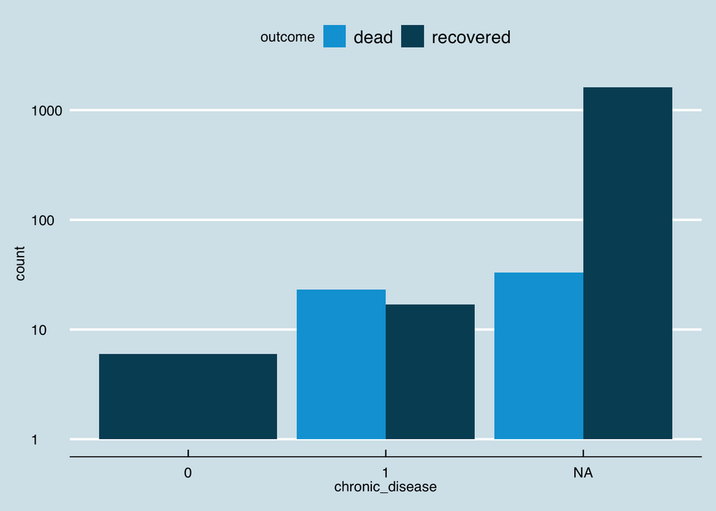

```r
covid_train %>%
    ggplot(aes(chronic_disease, fill = outcome)) +
    geom_bar(position = 'dodge') +
    scale_fill_economist() +
    scale_y_log10()
```

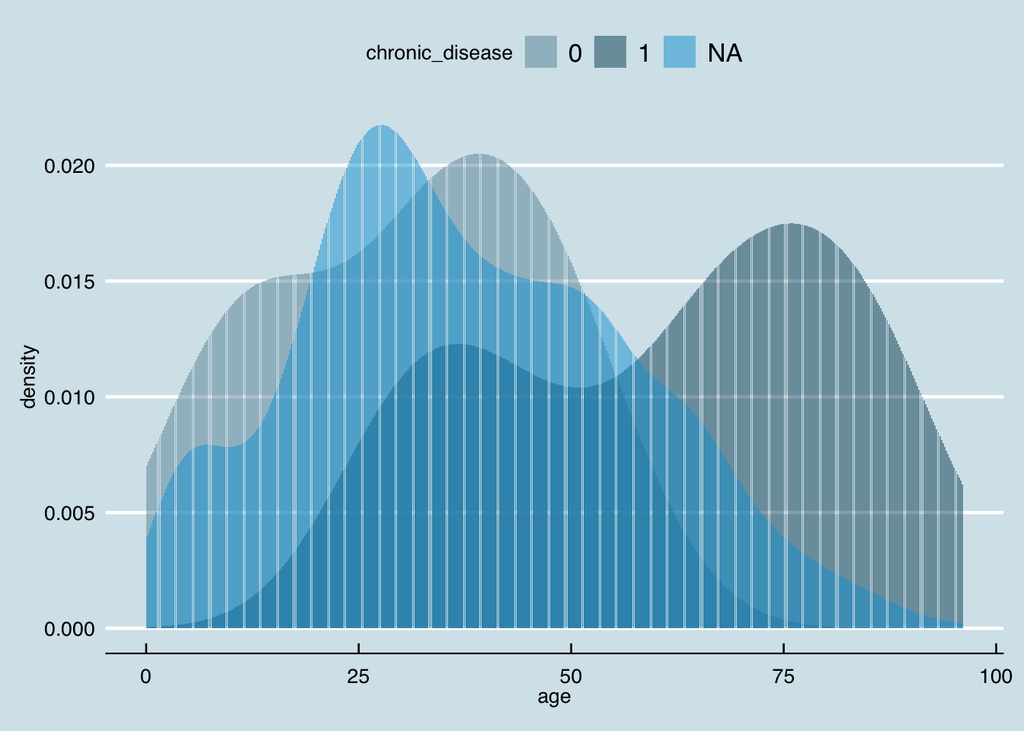

```r
covid_train %>%
    ggplot(aes(age, fill = chronic_disease)) +
    geom_histogram(stat = 'density', position = 'identity', alpha = 0.5) +
    scale_fill_economist()
```

We have very little data about dead patients with early symptoms

```r
covid_train %>%
    summarise_at(.vars = frequent_symptoms,
                 list(mort = ~sum((outcome == 'dead') * (.))/sum(.), sum = ~sum(.)))
```

| pneumonia\|pneumonitis_mort | pain_mort | fever_mort | cough_mort | sore throat_mort | fatigue_mort | headache_mort | dyspnea_mort | pneumonia\|pneumonitis_sum | pain_sum | fever_sum | cough_sum | sore throat_sum | fatigue_sum | headache_sum | dyspnea_sum |
| --- | --- | --- | --- | --- | --- | --- | --- | --- | --- | --- | --- | --- | --- | --- | --- |
| 0 | NaN | 0.05 | 0 | 0 | 0.5 | 0 | 1 | 22 | 0 | 140 | 20 | 2 | 2 | 1 | 1 |

Create simple dataset split and fit Logistic Lasso with CV

```r
covid_train = covid_train %>%
    mutate_if(is.character, as.factor)

train_mask = caret::createDataPartition(covid_train$outcome, p = 0.66)[[1]]
data_train = covid_train[train_mask,]
data_valid = covid_train[-train_mask,]

xlevs_train = data_train %>% select(-outcome)
xlevs <- lapply(xlevs_train[,sapply(xlevs_train, is.factor), drop = F], function(j){
    levels(j)
})
```

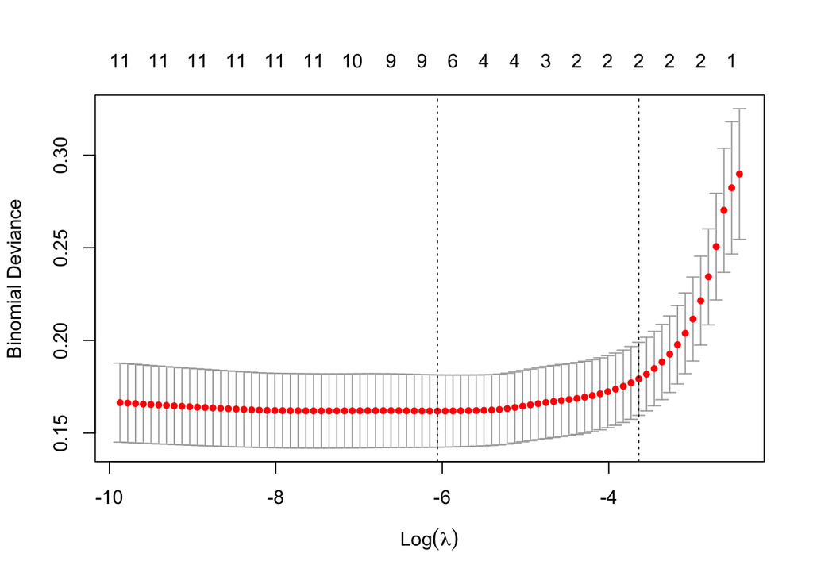

```r
pos = function(x, s, u = NULL) {
    x = ifelse(x > s, x - s, 0)
    if (!is.null(u))
        x = ifelse(x > (u - s), u - s, x)
    x
}

dtrain = model.matrix(~ age + pos(age, 50) - 1 + .,
                      data = data_train %>% select(-outcome))
dvalid = model.matrix(~ age + pos(age, 50) - 1 + .,
                      data = data_valid %>% select(-outcome))
cv_glmnet = cv.glmnet(dtrain, data_train$outcome == 'dead', family = 'binomial', nfolds = 10,
                   type.measure = 'deviance', keep = TRUE)
plot(cv_glmnet)
```

Coefficients for best model

```r
best_ind = which(cv_glmnet$lambda == cv_glmnet$lambda.min)
beta = cv_glmnet$glmnet.fit$beta[, best_ind]
beta
```

```
##                         age                pos(age, 50)
##                  0.04535254                  0.05198430
##                   sexfemale                     sexmale
##                 -0.15093117                  0.00000000
##                countryother            chronic_disease1
##                 -0.47095042                  3.74989174
##           chronic_diseaseNA `pneumonia|pneumonitis`TRUE
##                  0.00000000                  0.00000000
##                    painTRUE                   feverTRUE
##                  0.00000000                  0.24914877
##                   coughTRUE           `sore throat`TRUE
##                 -0.08619959                  0.00000000
##                 fatigueTRUE                headacheTRUE
##                  0.00000000                  0.00000000
##                 dyspneaTRUE
##                  0.00000000
```

Train 2 more GLM models with selected features

```r
lrm = glm(outcome == 'dead' ~ age + sex + country +
                              fever +I((chronic_disease == '1')),
          family = 'binomial', data = data_train)
lrm_simple = glm(outcome == 'dead' ~ age + sex + country + fever,
                 family = 'binomial', data = data_train)

summary(lrm)
```

```
##
## Call:
## glm(formula = outcome == "dead" ~ age + sex + country + fever +
##     I((chronic_disease == "1")), family = "binomial", data = data_train)
##
## Deviance Residuals:
##     Min       1Q   Median       3Q      Max
## -1.9019  -0.1672  -0.0760  -0.0385   3.7973
##
## Coefficients:
##                                 Estimate Std. Error z value Pr(>|z|)
## (Intercept)                     -9.15580    1.07909  -8.485  < 2e-16 ***
## age                              0.09408    0.01411   6.667 2.60e-11 ***
## sexmale                          0.45096    0.45624   0.988    0.323
## countryother                    -0.62097    0.47050  -1.320    0.187
## feverTRUE                        0.68506    0.74834   0.915    0.360
## I((chronic_disease == "1"))TRUE  4.08721    0.70367   5.808 6.31e-09 ***
## ---
## Signif. codes:  0 '***' 0.001 '**' 0.01 '*' 0.05 '.' 0.1 ' ' 1
##
## (Dispersion parameter for binomial family taken to be 1)
##
##     Null deviance: 324.91  on 1116  degrees of freedom
## Residual deviance: 168.69  on 1111  degrees of freedom
## AIC: 180.69
##
## Number of Fisher Scoring iterations: 8
```

```r
summary(lrm_simple)
```

```
##
## Call:
## glm(formula = outcome == "dead" ~ age + sex + country + fever,
##     family = "binomial", data = data_train)
##
## Deviance Residuals:
##     Min       1Q   Median       3Q      Max
## -1.4473  -0.1882  -0.0802  -0.0367   3.8216
##
## Coefficients:
##              Estimate Std. Error z value Pr(>|z|)
## (Intercept)  -9.37144    0.99574  -9.412  < 2e-16 ***
## age           0.10403    0.01325   7.849 4.18e-15 ***
## sexmale       0.63271    0.39789   1.590    0.112
## countryother -0.90340    0.43302  -2.086    0.037 *
## feverTRUE     0.72167    0.61102   1.181    0.238
## ---
## Signif. codes:  0 '***' 0.001 '**' 0.01 '*' 0.05 '.' 0.1 ' ' 1
##
## (Dispersion parameter for binomial family taken to be 1)
##
##     Null deviance: 324.91  on 1116  degrees of freedom
## Residual deviance: 210.82  on 1112  degrees of freedom
## AIC: 220.82
##
## Number of Fisher Scoring iterations: 8
```

Use DALEX library to create explainers :-) and show validation metrics - cutoff selected manually, but it’s not that important.

GLMNET and GLM model with chronic_disease feature have comparable fit. We will use GLM to present explanations

```r
lrm_perf = DALEX::model_performance(lrm_explain, cutoff = th)
lrm_simple_perf = DALEX::model_performance(lrm_simple_explain, cutoff = th)
cv_glmnet_perf = DALEX::model_performance(cv_glmnet_explain, cutoff = th)
lrm_perf
```

```
## Measures for:  classification
## recall   : 0.3684211
## precision: 0.5384615
## f1       : 0.4375
## accuracy : 0.9686411
## auc      : 0.818018
##
## Residuals:
##           0%          10%          20%          30%          40%
## -97.75840312  -6.04685441  -2.47724854  -1.26710781  -0.62273209
##          50%          60%          70%          80%          90%
##  -0.28350532  -0.16141046  -0.09518300  -0.04843133  -0.02303811
##         100%
##   0.98532307
```

```r
lrm_simple_perf
```

```
## Measures for:  classification
## recall   : 0.3157895
## precision: 0.375
## f1       : 0.3428571
## accuracy : 0.9599303
## auc      : 0.7658606
##
## Residuals:
##           0%          10%          20%          30%          40%
## -60.04176126  -7.60659540  -3.12710266  -1.57302006  -0.69464025
##          50%          60%          70%          80%          90%
##  -0.30264173  -0.17173782  -0.08458886  -0.04221967  -0.02242943
##         100%
##   0.98775075
```

```r
cv_glmnet_perf
```

```
## Measures for:  classification
## recall   : 0.4210526
## precision: 0.6666667
## f1       : 0.516129
## accuracy : 0.9738676
## auc      : 0.8182077
##
## Residuals:
##          0%         10%         20%         30%         40%         50%
## -97.3728290  -5.4029375  -2.2267556  -1.2076554  -0.7908296  -0.5521232
##         60%         70%         80%         90%        100%
##  -0.3940780  -0.3069395  -0.2275577  -0.1675109   0.8541615
```

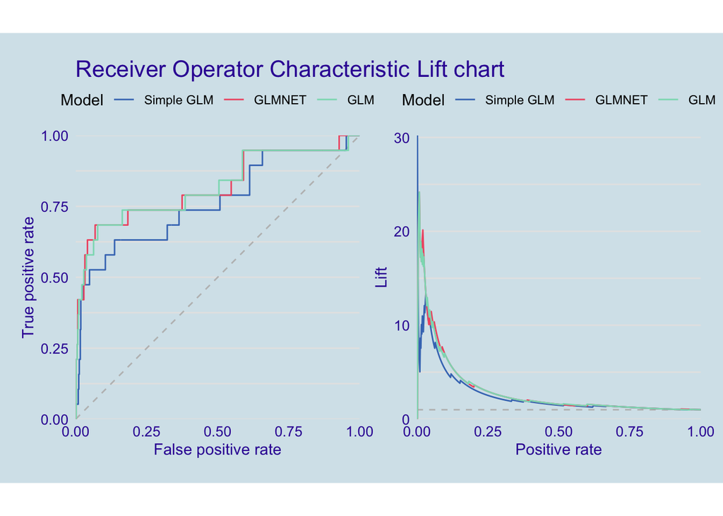

```r
p1 <- plot(lrm_perf, lrm_simple_perf, cv_glmnet_perf, geom = "roc")
p2 <- plot(lrm_perf, lrm_simple_perf, cv_glmnet_perf, geom = "lift")

library(patchwork)
p1 + p2
```

Present BreakDown with interactions for manually created cases.

```r
explain_data
```

| age | country | sex | chronic_disease | fever |
| --- | --- | --- | --- | --- |
| 5 | China | male | 0 | FALSE |
| 15 | other | male | 0 | TRUE |
| 30 | China | female | 1 | FALSE |
| 45 | other | female | 0 | TRUE |
| 50 | China | male | 0 | FALSE |
| 55 | other | male | 1 | TRUE |
| 60 | China | female | 0 | FALSE |
| 65 | other | female | 0 | TRUE |
| 70 | China | male | 1 | FALSE |
| 75 | other | male | 0 | TRUE |

[output cut: 2 more lines]

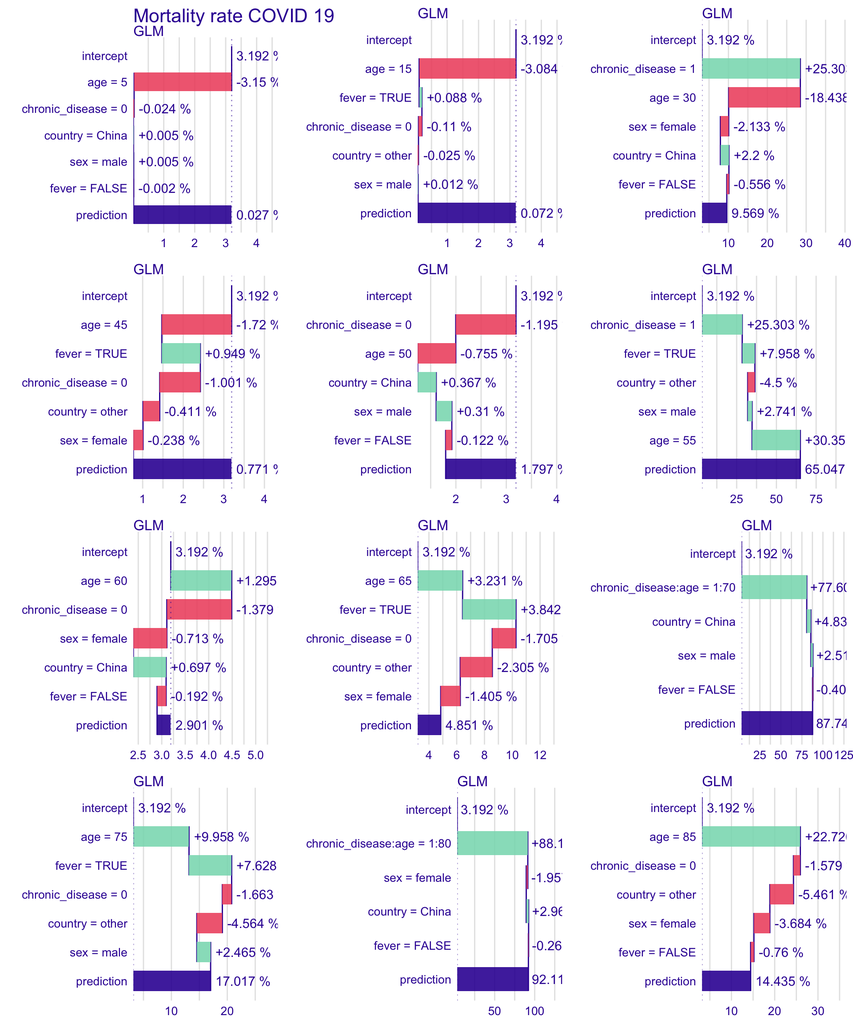

```r
grid.arrange(ps[[1]], ps[[2]], ps[[3]], ps[[4]],
             ps[[5]], ps[[6]], ps[[7]], ps[[8]],
             ps[[9]], ps[[10]], ps[[11]], ps[[12]], nrow = 4)
```